# lab3b_2.2

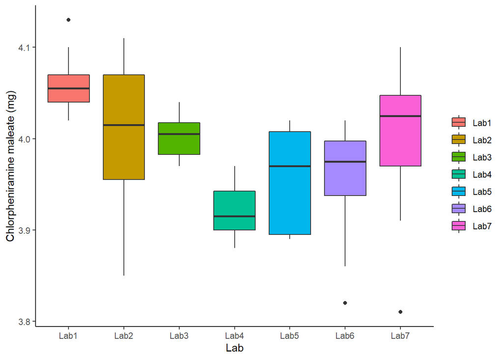

*Figure 1: Boxplots of determinations of amounts of chlorpheniramine maleate in tablets by seven laboratories.*

**The boxplots in Figure 1 show some differences in the medians. Are these differences significant? We can address this by asking a variety of questions.**

## Question 1.

**Is the mean level of chlorpheniramine maleate in tablets from Lab 1 different from 4.0? State the null hypothesis.**

We use a one sample t-test. $H_0: \mu_i=4$ vs. $H_1:\mu_1\neq4$

```r
t.test(tablet$Lab1, mu = 4)
```

```
##
##  One Sample t-test
##
## data:  tablet$Lab1
## t = 6.0157, df = 9, p-value = 0.0001986
## alternative hypothesis: true mean is not equal to 4
## 95 percent confidence interval:
##  4.038685 4.085315
## sample estimates:
## mean of x
##     4.062
```

Therefore, the mean level in Lab 1 is different to 4.

## Question 2.

**Is the mean level of chlorpheniramine maleate in tablets from Lab 1 different from that from Lab 3?**

Here we use a two sample t-test. $H_0:\mu_1=u_3$ vs. $H_1:\mu_1\neq \mu_3$

```r
t.test(tablet$Lab1, tablet$Lab3)
```

```
##
##  Welch Two Sample t-test
##
## data:  tablet$Lab1 and tablet$Lab3
## t = 4.6692, df = 16.227, p-value = 0.0002475
## alternative hypothesis: true difference in means is not equal to 0
## 95 percent confidence interval:
##  0.03224345 0.08575655
## sample estimates:
## mean of x mean of y
##     4.062     4.003
```

Here we can see that the means of Lab1 and Lab3 results are different.

## Question 3.

**Perform a one-way ANOVA to test if the mean levels of chlorpheniramine maleate differ across the seven labs.**

```r
lab_anova = aov(measurement ~ lab, data = tabdat)
summary(lab_anova)
```

```
##             Df Sum Sq  Mean Sq F value   Pr(>F)
## lab          6 0.1247 0.020790    5.66 9.45e-05 ***
## Residuals   63 0.2314 0.003673
## ---
## Signif. codes:  0 '***' 0.001 '**' 0.01 '*' 0.05 '.' 0.1 ' ' 1
```

$F = 5.66\mbox{, df}=6,63\mbox{, }p<0.0001$

Here we can see that the p-value is << 0.05 therefore, we can conclude that there must be at least 2 groups that differ in means.

## Question 4.

**Obtain a QQ plot of the residuals and comment on the validity of the ANOVA assumptions.**

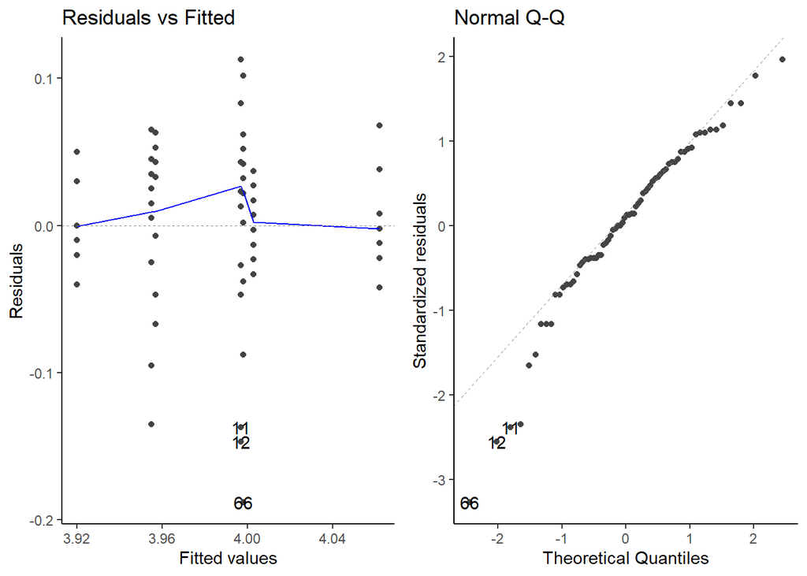

On the left plot we can see that the blue line isn’t close to 0 therefore, the middle groups don’t have much equal variance.

And on the right plot we can assume normality because most of the points lie on the QQ line, however, there are a few towards the low end that deviates from this line. Furthermore, we can rely on the central limit theorem to ensure our inferences are valid.

## Question 5.

**Perform pairwise post hoc tests to determine which labs are significantly different.**

To do this we can once again use the emmeans package.

| contrast | estimate | SE | df | t.ratio | p.value |
| --- | --- | --- | --- | --- | --- |
| Lab1 - Lab4 | 0.142 | 0.0271 | 63 | 5.2392 | 0.0000 |
| Lab1 - Lab5 | 0.105 | 0.0271 | 63 | 3.8740 | 0.0054 |
| Lab1 - Lab6 | 0.107 | 0.0271 | 63 | 3.9478 | 0.0042 |

Here we have filtered out all the significant contrasts and tabulated them above. Furthermore, all the pairwise mean differences are plotted.

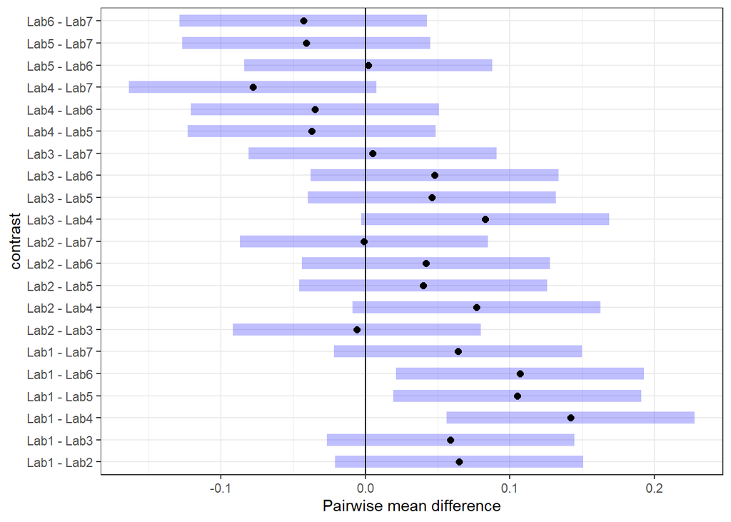

We can conclude that Lab1 is significantly different to Labs 4,5 and 6.

## Question 6.

**Use a rank based approach to testing for a difference between the means of the 7 labs.**

```r
kruskal.test(measurement ~ factor(lab), data = tabdat)
```

```
##
##  Kruskal-Wallis rank sum test
##
## data:  measurement by factor(lab)
## Kruskal-Wallis chi-squared = 29.606, df = 6, p-value = 4.67e-05
```

$\chi^2=29.6 \mbox{, df}=6\mbox{, }p<0.001$

Therefore, the Kruskal-Wallis test shows that there is significance difference between the means of the 7 labs.